# PicnicHealth Hemophilia B subset Analysis

Jaison Jacob

2022-10-23

```r
knitr::opts_chunk$set(echo = TRUE, message = FALSE)
library(ggplot2)
library(PicnicHealth)
library(PicnicBlanket)
library(magrittr)
library(DT)
library(ggpmisc)
library(kableExtra)

filename <- "/Users/poops/Projects/hemB/sample_dataset/data"
hemB <- load_data_set(filename)
```

## Hemophilia B test dataset exploration

The goal of this analysis is to assess the hypothesis that compared to mild or moderate hemophilia B patients, patients with severe hemophilia B have:

1. higher healthcare utilization
2. more bleeds.

Our definition of the phenotypic severity will be as follows:

- Patients with a baseline factor IX level of <1% have severe hemophilia
- Patients with a baseline factor IX level of 1-5% have moderate hemophilia
- Patients with a baseline factor IX level of 5-50% have mild hemophilia

Table 1. Patient characteristics for this exploratory cohort is shown above.

| **Characteristic** | **N = 10**<sup>1</sup> |
| --- | --- |
| Sex |  |
| Male | 10 (100%) |
| Race |  |
| Asian | 1 (10%) |
| Black or African American | 2 (20%) |
| Unknown | 1 (10%) |
| White | 6 (60%) |
| Ethnicity |  |
| Hispanic or Latino | 1 (10%) |
| Not Hispanic or Latino | 5 (50%) |
| Unknown | 4 (40%) |
| Age | 30 (20, 46) |
| Total Years of Clinical Documents | 20.0 (14.3, 21.4) |
| Total Years of Visits | 14.3 (11.2, 19.9) |
| Number of Providers | 31 (26, 58) |
| Number of Care Sites | 10 (8, 14) |
| Number of Hospitalizations | 9 (3, 19) |
| Total Hospital Days | 11 (4, 25) |

<sup>1</sup> n (%); Median (IQR)

Table 1. shows that the paients are all Males, consistent with the fact that this is an X-linked genetic disease. Now let us start diving into the *baseline* data and create data subsets for easy exploration and analysis. The code below parses the baseline dataset and creates a severity index using our definitions above based on the Coagulation factor IX activity actual/normal in Platelet poor plasma by Coagulation assay.

```r
severity_data <- hemB$baseline %>%
  dplyr::filter(measurement_concept_id == "8b961efa-cc89-55c3-bcd8-e83c74cb4612") %>%
  dplyr::mutate(value_as_range = tidyr::replace_na(value_as_range,"{}")) %>%
  dplyr::mutate(tidyjson::spread_all(value_as_range)) %>%
  dplyr::mutate(baseline_value = dplyr::case_when(
    recorded_value_type == "number" ~ value_as_number,
    type %in% c("lessThan", "lessThanOrEqualTo") ~ borderValue - 0.1,
    type %in% c("greaterThanOrEqualTo", "greaterThan") ~ borderValue + 0.1,
    type == "between" ~ (lowValue + highValue)/2)) %>%
  dplyr::mutate(b_severity = dplyr::case_when(
    baseline_value <  1 ~ "Severe",
    baseline_value >= 1 & baseline_value <= 5 ~ "Moderate",
    baseline_value > 5 & baseline_value <=  50 ~ "Mild",
    baseline_value > 50 ~ "Normal")) %>%
  dplyr::group_by(person_id) %>%
  dplyr::filter(baseline_value == min(baseline_value)) %>%
  dplyr::distinct( person_id, baseline_value, b_severity ) %>%
  dplyr::arrange( baseline_value )

severity_data$person_id = factor(severity_data$person_id,
                                 levels = severity_data$person_id)
```

Table 2. Severity Data

| person_id | baseline_value | b_severity |
| --- | --- | --- |
| a9ba2a66-1991-4c9c-bbb7-7e6bddff65c8 | 0.0 | Severe |
| 2376bd41-5457-4d00-a6d3-ebe8ea68edec | 0.9 | Severe |
| 7c92ea19-9f49-4477-a67c-ba5374aa08cb | 0.9 | Severe |
| 6fbad7ae-5d42-48ff-b096-e8d643d383bd | 0.9 | Severe |
| cefda20a-2648-4211-ba99-09b65da8ac68 | 2.0 | Moderate |
| 86337351-2c6f-4b5d-8b43-378fa6006b96 | 2.0 | Moderate |
| b64bd4b8-bfe8-4b94-b0b6-86e5616bf66c | 3.0 | Moderate |
| d1da4355-fcc1-41e1-8c9a-55e6a71d7713 | 4.0 | Moderate |
| 43a36d23-b370-4a17-a9f1-6ed03060390d | 11.1 | Mild |
| 0ba0d20a-997a-482d-b9ee-00fc203dc3d7 | 12.0 | Mild |

Now we will explore the *visit* data to obtain healthcare utilization information from *Inpatient Visits* and *Outpatient Visits* columns.

```r
hospitalization_data <- hemB$visit %>%
  dplyr::mutate(hosp_days = difftime(hemB$visit$visit_end_date,
                                     hemB$visit$visit_start_date, units = "days") %>%
                  as.integer) %>%
  dplyr::group_by( person_id, visit_concept_name) %>%
  dplyr::mutate( visit_type_count = dplyr::n(),
                 total_hosp_days = sum(hosp_days)) %>%
  dplyr::ungroup() %>%
  dplyr::distinct( person_id, visit_concept_name, visit_type_count, total_hosp_days) %>%
  tidyr::pivot_wider( names_from = visit_concept_name,
                      values_from = c(visit_type_count, total_hosp_days)) %>%
  dplyr::select( person_id,
                 in_visits  = `visit_type_count_Inpatient Visit`,
                 out_visits = `visit_type_count_Outpatient Visit`,
                 overnight_hosp = `total_hosp_days_Inpatient Visit`) %>%
  dplyr::left_join( severity_data, by = "person_id") %>%
  dplyr::arrange( baseline_value ) %>%
  dplyr::mutate( total_visits = tidyr::replace_na(in_visits,0) +
                   tidyr::replace_na(out_visits, 0))

hospitalization_data$person_id = factor(hospitalization_data$person_id,
                                 levels = hospitalization_data$person_id)

age_data <- hemB$person %>%
  dplyr::mutate(age_at_enroll = difftime(enrollment_date,
                                         date_of_birth,
                                         units = "days")/365 %>%
  as.numeric()) %>%
  dplyr::select(person_id,age_at_enroll,
                sex = sex_concept_name,
                race  = race_concept_name) %>%
  dplyr::left_join( severity_data, by = "person_id") %>%
  dplyr::arrange( baseline_value ) %>%
  dplyr::mutate(age_at_enroll = sprintf("%0.1f", age_at_enroll))

age_data$person_id = factor(age_data$person_id,
                                 levels = age_data$person_id)

age_data <- dplyr::left_join( age_data, severity_data)

hospitalization_data <- dplyr::left_join( age_data, hospitalization_data) %>%
  dplyr::mutate( label1 = sprintf("Age = %s; Overnights = %s",
                                 age_at_enroll,in_visits),
                 label2 = sprintf("Age = %s; Overnights = %s",
                                 age_at_enroll,out_visits),
                 label3 = sprintf("Age = %s; Overnights = %s",
                                 age_at_enroll,overnight_hosp),
                 )
```

Table 2. Hospitalization Data

| person_id | age_at_enroll | sex | race | baseline_value | b_severity | in_visits | out_visits | overnight_hosp | total_visits |
| --- | --- | --- | --- | --- | --- | --- | --- | --- | --- |
| a9ba2a66-1991-4c9c-bbb7-7e6bddff65c8 | 23.9 | Male | Black or African American | 0.0 | Severe | 8 | 92 | 4 | 100 |
| 2376bd41-5457-4d00-a6d3-ebe8ea68edec | 8.8 | Male | Asian | 0.9 | Severe | 21 | 55 | 6 | 76 |
| 7c92ea19-9f49-4477-a67c-ba5374aa08cb | 19.6 | Male | White | 0.9 | Severe | 12 | 179 | 7 | 191 |
| 6fbad7ae-5d42-48ff-b096-e8d643d383bd | 43.4 | Male | White | 0.9 | Severe | 110 | 308 | 71 | 418 |
| 86337351-2c6f-4b5d-8b43-378fa6006b96 | 19.5 | Male | White | 2.0 | Moderate | 85 | 132 | 50 | 217 |
| cefda20a-2648-4211-ba99-09b65da8ac68 | 49.5 | Male | White | 2.0 | Moderate | 7 | 99 | 2 | 106 |
| b64bd4b8-bfe8-4b94-b0b6-86e5616bf66c | 9.1 | Male | White | 3.0 | Moderate | 10 | 102 | 0 | 112 |
| d1da4355-fcc1-41e1-8c9a-55e6a71d7713 | 68.9 | Male | NA | 4.0 | Moderate | NA | 39 | NA | 39 |
| 43a36d23-b370-4a17-a9f1-6ed03060390d | 35.5 | Male | White | 11.1 | Mild | 2 | 50 | 0 | 52 |
| 0ba0d20a-997a-482d-b9ee-00fc203dc3d7 | 47.4 | Male | Black or African American | 12.0 | Mild | NA | 56 | NA | 56 |

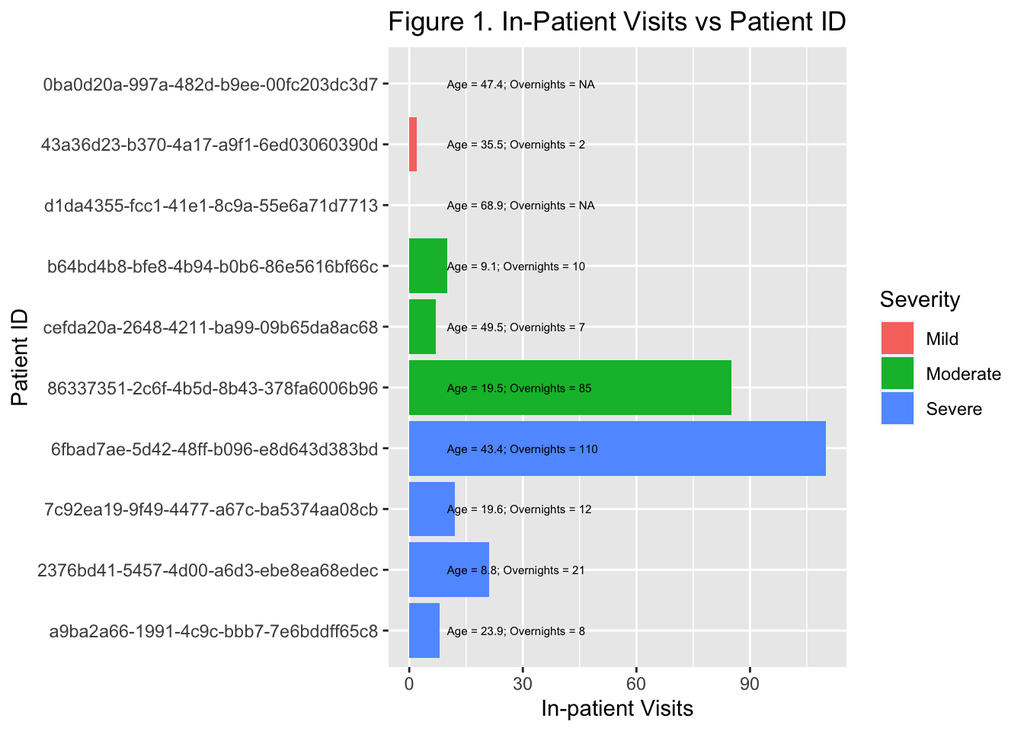

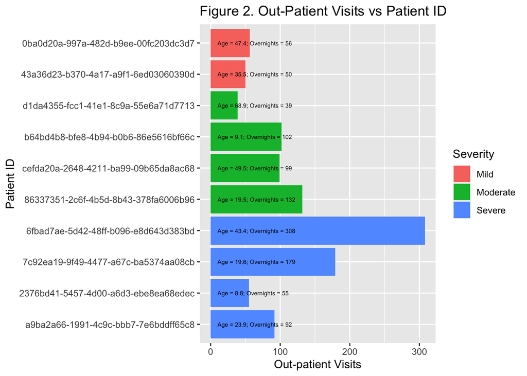

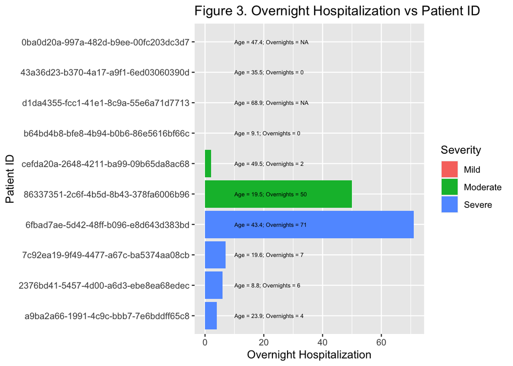

No strong correlations seen between severity as defined and Out-patient vist counts. However, there seems to be a trend with in-patient and overnight hospitalizations. There seems to be one patient classified as moderate that seems to be breaking the trend. Against all good practices we will attempt to plot this and fit a regression line throug these datapoints.

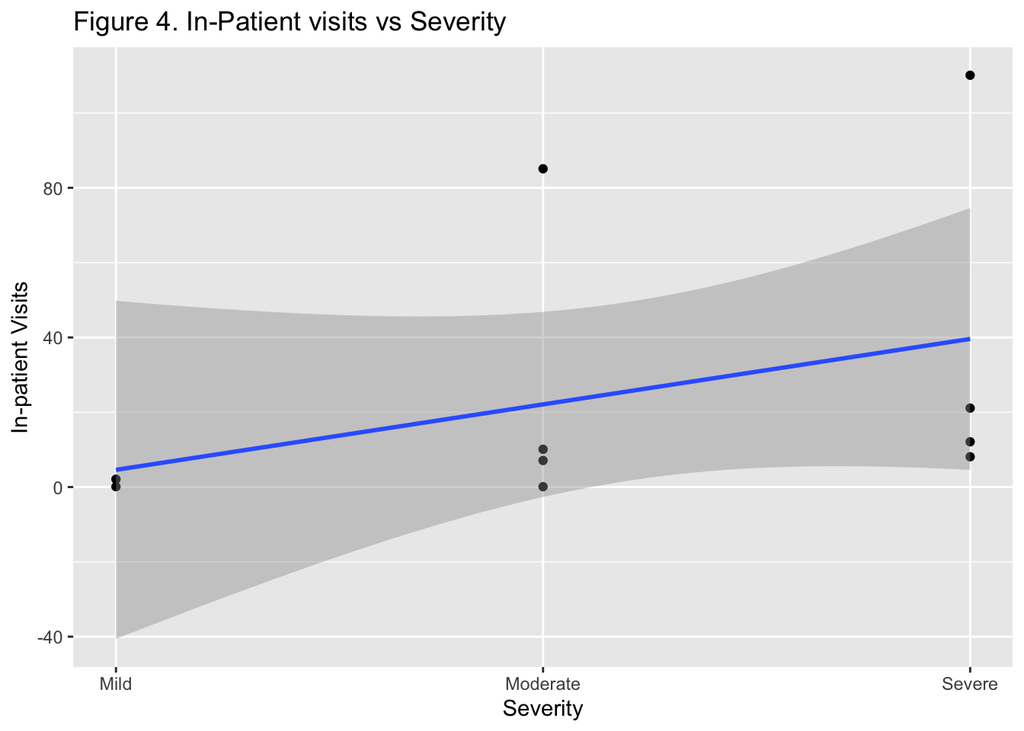

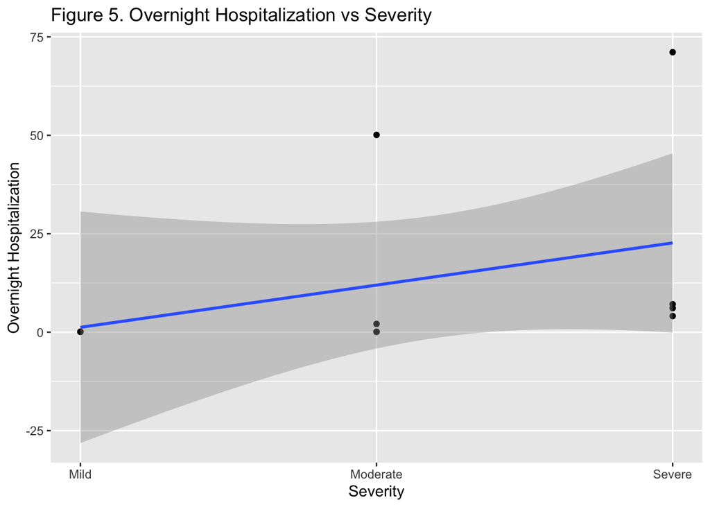

Now we will explore the *bleed* data to explore the relationship between severity and bleeding episodes.

```r
bleeds <- hemB$bleed %>%
  dplyr::group_by( person_id, bleed_type_concept_name ) %>%
  dplyr::summarise(count = dplyr::n()) %>%
  dplyr::left_join( age_data) %>%
  dplyr::ungroup() %>%
  dplyr::group_by( person_id) %>%
  dplyr::mutate( total_episodes = sum(count)) %>%
  dplyr::ungroup() %>%
  dplyr::arrange( baseline_value, total_episodes, count) %>%
  dplyr::left_join(age_data)

bleeds$person_id = factor( bleeds$person_id,
                               levels = levels(age_data$person_id))

bleeds <- bleeds %>% droplevels
```

[figure not shown]

Table 3. Bleeding episodes Data

| person_id | baseline_value | b_severity | total_episodes |
| --- | --- | --- | --- |
| a9ba2a66-1991-4c9c-bbb7-7e6bddff65c8 | 0.0 | Severe | 43 |
| 2376bd41-5457-4d00-a6d3-ebe8ea68edec | 0.9 | Severe | 27 |
| 7c92ea19-9f49-4477-a67c-ba5374aa08cb | 0.9 | Severe | 74 |
| 6fbad7ae-5d42-48ff-b096-e8d643d383bd | 0.9 | Severe | 111 |
| cefda20a-2648-4211-ba99-09b65da8ac68 | 2.0 | Moderate | 13 |
| 86337351-2c6f-4b5d-8b43-378fa6006b96 | 2.0 | Moderate | 39 |
| b64bd4b8-bfe8-4b94-b0b6-86e5616bf66c | 3.0 | Moderate | 11 |
| d1da4355-fcc1-41e1-8c9a-55e6a71d7713 | 4.0 | Moderate | 1 |
| 43a36d23-b370-4a17-a9f1-6ed03060390d | 11.1 | Mild | 4 |
| 0ba0d20a-997a-482d-b9ee-00fc203dc3d7 | 12.0 | Mild | 9 |

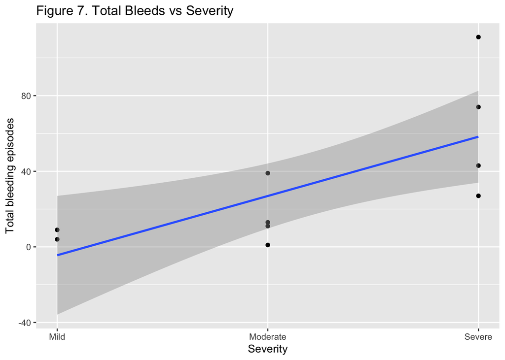

## Conclusion

There does appear to be a trend towards higher healthcare utilization and bleeding episodes with the severity definitions. However, it would be unwise to make any statistical conclusions from this dataset. It is unclear if the *bleed* was recorded systematically during a set period and if the bleed data were recorded in light of any prophylactic Factor IX usage. For example , there is one patient, 86337351-2c6f-4b5d-8b43-378fa6006b9, with a *Moderate* classification, who is a 20 year old patient. This patient has higher hospitalizations and more bleed episodes that are similar to those in the severe category. Several variables can potentially affect these. It might be worth asking if this patient for example, has better access to health care or someone invloved in activities (like contact sports) that could increase the chances of bleeding episodes. If patients are on phrophylactic therapy, it will be good to understand the dose, time from last admininstration of the therapy before recording the coagulation asaay, halflife of the specific drug used etc. A larger dataset could potentially be helpful and more discussion and understanding around the data collection is needed.